# ggplot2でX軸の大小を反転させる方法 (factor)

Toshiaki Ara

2018-12-16

# はじめに

## 無指定の場合

ggplot2で描画する際に`coord_flip()`を使用するとX軸とY軸を入れ替えることができる。ただし、その場合には順番が小さい方が下にきてしまい、思い通りの図にならない。

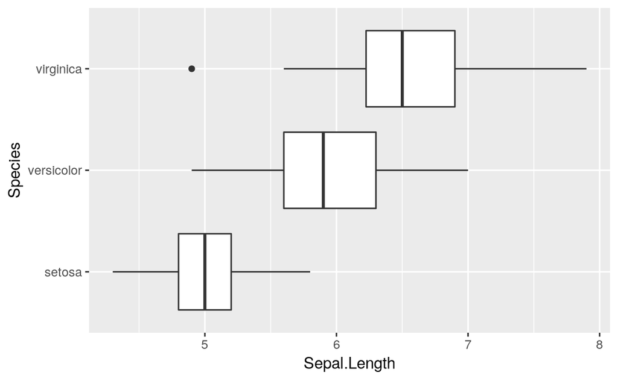

```r
library(ggplot2)

p <- ggplot(iris)
p + aes(x = Species, y = Sepal.Length) +
     geom_boxplot() +
     coord_flip()
```

## （追記）reorder関数を使用する場合

[このサイト](https://gist.github.com/jennybc/6f3fa527b915b920fdd5)の内容を参考にした。

`reorder`関数を使用することでfactorの順序を変えることができる。この時`dplyr`パッケージの`desc`関数で降順に変換する。

ただし、この後にいくつか例を示しているが、 `forcats`パッケージの`fct_rev`関数を使用する方法が最も簡単である。

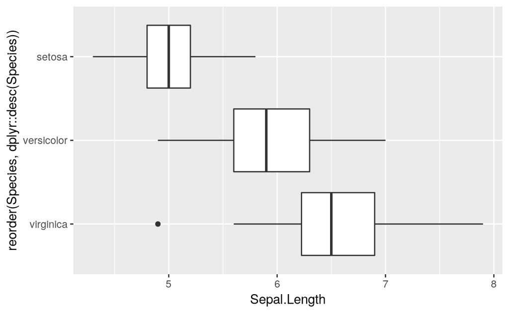

```r
## library(dplyr)  ## desc

p + aes(x = reorder(Species, dplyr::desc(Species)),
        y = Sepal.Length) +
     geom_boxplot() +
    coord_flip()
```

### 以下の内容は古い

今回の`iris`データの`Species`列はfactorであるため、 `as.integer`関数で整数に変換する。その後、正負を反転させることで順序を逆にする。

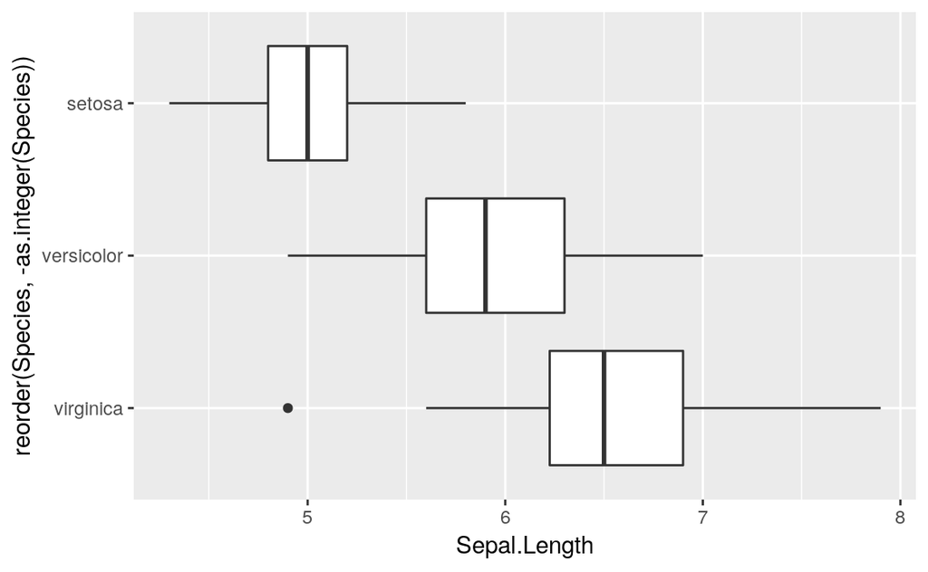

```r
p + aes(x = reorder(Species, -as.integer(Species)),
         y = Sepal.Length) +
     geom_boxplot() +
     coord_flip()
```

## （追記）forcatsパッケージのfct_rev関数を使用する場合

`reorder`関数を使用した場合には、 `-as.integer(Species)`の部分が何をしているのかが一見分かりにくい。

そこで`forcats`パッケージの`fct_rev`関数を使用した方法を示す。この関数はfactorの順序を反転させるものである。以前`fct_reorder`関数を使用した例を紹介したが、それよりも簡潔に記載できる事が分かった。

したがって、個人的にはこの方法を使用することにする。

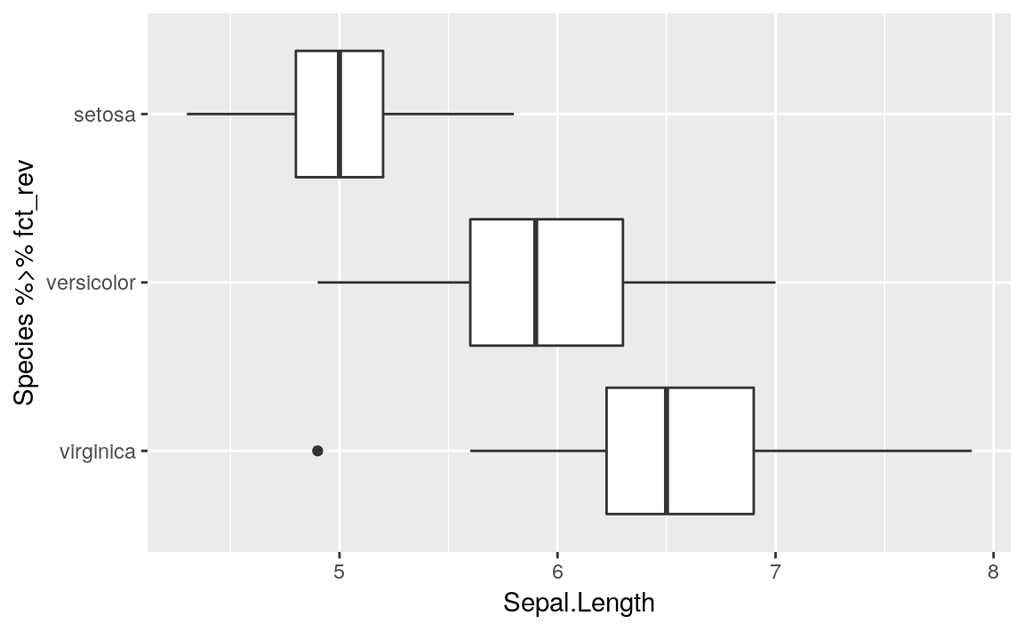

```r
library(forcats)

p + aes(x = Species %>% fct_rev, y = Sepal.Length) +
     geom_boxplot() +
     coord_flip()
```

## （古い内容）forcatsパッケージのfct_reorder関数を使用する場合

`reorder`関数を使用した場合には、 `-as.integer(Species)`の部分が何をしているのかが一見分かりにくい。

そこで`forcats`パッケージの`fct_reorder`関数を使用した方法を示す。 `as.integer(Species)`で整数に変換するのは同じである。ただし、引数で`.desc = TRUE`を指定することで逆順にしていることが明瞭となる。

したがって、個人的にはこの方法を使用することにする。

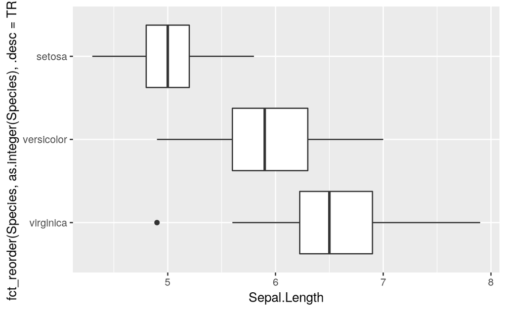

```r
library(forcats)   ## fct_reorder

p + aes(x = fct_reorder(Species, as.integer(Species), .desc = TRUE),
        y = Sepal.Length) +
    geom_boxplot() +
    coord_flip()
```